# Analysis of N400 amplitude data from two experiments on processing of gender-related stereotypes

## 4.2 Dataset structure and summary

Overview of the final dataset .

```r
# Dataset dimensions
cat("Dataset Dimensions:\n")
```

```
## Dataset Dimensions:
```

```r
cat(sprintf("  Total observations: %d\n", nrow(exp2_all_data)))
```

```
##   Total observations: 127626
```

```r
cat(sprintf("  Total variables: %d\n", ncol(exp2_all_data)))
```

```
##   Total variables: 17
```

```r
cat(sprintf("  Unique participants: %d\n", n_distinct(exp2_all_data$ParticipantID)))
```

```
##   Unique participants: 60
```

```r
cat(sprintf("  Unique itemss: %d\n", n_distinct(exp2_all_data$WordID)))
```

```
##   Unique itemss: 192
```

```r
# Trial counts by condition
cat("\nTrials per Condition:\n")
```

```
##
## Trials per Condition:
```

```r
count_trial <- compute_trial_counts(exp2_all_data)

exp2_trial_summary <- count_trial %>%
  group_by(Condition) %>%
  summarise(
    n_participants = n(),
    mean_trials = mean(trial, na.rm = TRUE),
    sd_trials = sd(trial, na.rm = TRUE),
    min_trials = min(trial, na.rm = TRUE),
    max_trials = max(trial, na.rm = TRUE),
    .groups = "drop"
  )

for (i in 1:nrow(exp2_trial_summary)) {
  cat(sprintf("  %s: %d participants, M = %.1f trials (SD = %.1f, range: %d-%d)\n",
              exp2_trial_summary$Condition[i],
              exp2_trial_summary$n_participants[i],
              exp2_trial_summary$mean_trials[i],
              exp2_trial_summary$sd_trials[i],
              exp2_trial_summary$min_trials[i],
              exp2_trial_summary$max_trials[i]))
}
```

```
##   Congruent.Atypical: 60 participants, M = 88.4 trials (SD = 9.6, range: 45-96)
##   Congruent.Typical: 60 participants, M = 88.6 trials (SD = 9.5, range: 46-96)
##   Incongruent.Atypical: 60 participants, M = 88.9 trials (SD = 9.1, range: 48-96)
##   Incongruent.Typical: 60 participants, M = 88.6 trials (SD = 9.6, range: 47-96)
```

```r
# Categorical variables used in models
cat("\n\nCategorical Variables (Levels):\n")
```

```
##
##
## Categorical Variables (Levels):
```

```r
cat(sprintf("  Participant Gender: %s\n", paste(levels(exp2_all_data$PtpGender), collapse = ", ")))
```

```
##   Participant Gender: Female, Male
```

```r
cat(sprintf("  Congruency: %s\n", paste(levels(exp2_all_data$Congruency), collapse = ", ")))
```

```
##   Congruency: Incongruent, Congruent
```

```r
cat(sprintf("  VoiceGenderedness: %s\n", paste(levels(exp2_all_data$VoiceGenderedness), collapse = ", ")))
```

```
##   VoiceGenderedness: High, Low
```

```r
cat(sprintf("  Electrode Regions (Frontality): %s\n", paste(unique(exp2_all_data$Frontality), collapse = ", ")))
```

```
##   Electrode Regions (Frontality): C, CP
```

```r
# Continuous variables used in models
cat("\n\nContinuous Variables Summary:\n")
```

```
##
##
## Continuous Variables Summary:
```

```r
cat("\nDependent Variable:\n")
```

```
##
## Dependent Variable:
```

```r
print(summary(exp2_all_data$value))
```

```
##     Min.  1st Qu.   Median     Mean  3rd Qu.     Max.
## -45.4770  -4.3990   1.0250   0.9614   6.3750  48.6690
```

```r
cat("\nTrial Order (original and centered):\n")
```

```
##
## Trial Order (original and centered):
```

```r
cat(sprintf("  Order: Range = [%d, %d], Mean = %.2f\n",
            min(exp2_all_data$Order), max(exp2_all_data$Order), mean(exp2_all_data$Order)))
```

```
##   Order: Range = [1, 386], Mean = 193.27
```

```r
# Center Order variable for models
exp2_all_data <- exp2_all_data %>%
  mutate(Order_c = Order - mean(Order))

cat(sprintf("  Order_c (centered): Range = [%.2f, %.2f], Mean = %.2f\n",
            min(exp2_all_data$Order_c), max(exp2_all_data$Order_c), mean(exp2_all_data$Order_c)))
```

```
##   Order_c (centered): Range = [-192.27, 192.73], Mean = 0.00
```

```r
# Random effects variables
cat("\n\nRandom Effects Grouping Variables:\n")
```

```
##
##
## Random Effects Grouping Variables:
```

```r
cat(sprintf("  Participants (ParticipantID): %d levels\n", n_distinct(exp2_all_data$ParticipantID)))
```

```
##   Participants (ParticipantID): 60 levels
```

```r
cat(sprintf("  Words (WordID): %d levels\n", n_distinct(exp2_all_data$WordID)))
```

```
##   Words (WordID): 192 levels
```

```r
cat(sprintf("  Electrode Channels (ChLabel): %d levels\n", n_distinct(exp2_all_data$ChLabel)))
```

```
##   Electrode Channels (ChLabel): 6 levels
```

```r
cat("\n\nDataset ready for statistical modeling.\n")
```

```
##
##
## Dataset ready for statistical modeling.
```

## 4.3 Analysis: Congruency × Participant Gender × Voice Genderedness

Congruency effects only for female participants, with different directions for highly gendered voices vs. less gendered voices. No significant effects of Congruency for male participants, with either highly gendered or less gendered voices in the stimuli.

```r
# Run main model
# 1. Build a model with maximal fixed effects structure based on the experimental design and simplest random structure with random intercepts for ParticipantID, WordID and ChLabel.
exp2_model_main <- run_lmer_model(
  value ~ Congruency * PtpGender * VoiceGenderedness +
    (1 | ParticipantID) + (1 | WordID) + (1 | ChLabel),
  # data = data_main
  data = exp2_all_data
)
```

```
## Linear mixed model fit by maximum likelihood . t-tests use Satterthwaite's
##   method [lmerModLmerTest]
## Formula: formula
##    Data: data
## Control: control
##
##       AIC       BIC    logLik -2*log(L)  df.resid
##  886837.4  886954.5 -443406.7  886813.4    127614
##
## Scaled residuals:
##     Min      1Q  Median      3Q     Max
## -5.8118 -0.6349  0.0036  0.6472  5.3160
##
## Random effects:
##  Groups        Name        Variance Std.Dev.
##  WordID        (Intercept)  2.1476  1.4655
##  ParticipantID (Intercept)  7.6878  2.7727
##  ChLabel       (Intercept)  0.0463  0.2152
##  Residual                  60.5289  7.7800
## Number of obs: 127626, groups:  WordID, 192; ParticipantID, 60; ChLabel, 6
##
## Fixed effects:
##                                                Estimate    Std. Error
## (Intercept)                                    0.929407      0.384261
## Congruency1                                   -0.066025      0.043596
## PtpGender1                                     0.409899      0.717647
## VoiceGenderedness1                             0.010525      0.043583
## Congruency1:PtpGender1                        -0.071166      0.087200
## Congruency1:VoiceGenderedness1                -0.378718      0.087172
## PtpGender1:VoiceGenderedness1                 -0.006726      0.087174
## Congruency1:PtpGender1:VoiceGenderedness1     -0.709398      0.174339
##                                                      df t value  Pr(>|t|)
## (Intercept)                                   75.040261   2.419     0.018 *
## Congruency1                               127382.065637  -1.514     0.130
## PtpGender1                                    59.988829   0.571     0.570
## VoiceGenderedness1                        127374.896199   0.241     0.809
## Congruency1:PtpGender1                    127383.970919  -0.816     0.414
## Congruency1:VoiceGenderedness1            127376.200575  -4.344 0.0000140 ***
## PtpGender1:VoiceGenderedness1             127376.918214  -0.077     0.938
## Congruency1:PtpGender1:VoiceGenderedness1 127375.466290  -4.069 0.0000472 ***
```

[output cut: 12 more lines]

```
##
## Analysis of Deviance Table (Type III Wald chisquare tests)
##
## Response: value
##                                          Chisq Df Pr(>Chisq)
## (Intercept)                             5.8501  1    0.01558 *
## Congruency                              2.2937  1    0.12990
## PtpGender                               0.3262  1    0.56788
## VoiceGenderedness                       0.0583  1    0.80918
## Congruency:PtpGender                    0.6661  1    0.41443
## Congruency:VoiceGenderedness           18.8744  1 0.00001396 ***
## PtpGender:VoiceGenderedness             0.0060  1    0.93850
## Congruency:PtpGender:VoiceGenderedness 16.5574  1 0.00004720 ***
## ---
## Signif. codes:  0 '***' 0.001 '**' 0.01 '*' 0.05 '.' 0.1 ' ' 1
```

```r
# 2. Augment random effects structure by adding random slopes for Congruency and VoiceGenderedness for ParticipantID and WordID, while keeping the same fixed effects structure.
exp2_model_main <- run_lmer_model(
  value ~ Congruency * PtpGender * VoiceGenderedness +
    (1 + Congruency*VoiceGenderedness | ParticipantID) + (1 + Congruency * VoiceGenderedness * PtpGender | WordID) + (1 | ChLabel),
  data = exp2_all_data,
  auto_simplify = TRUE,
  time_limit = 600
)
```

```
## ======================================================
## === Searching for optimal RE structure
## === Fixed effects: value ~ Congruency * PtpGender * VoiceGenderedness
## ======================================================
##
## Testing 9 candidate RE structure(s)...
##
## [1/9] maximal (correlated)
##        RE:  c("(1 + Congruency + VoiceGenderedness + Congruency:VoiceGenderedness | )", "(    ParticipantID)") + c("(1 + Congruency + VoiceGenderedness + PtpGender + Congruency:VoiceGenderedness + )", "(    Congruency:PtpGender + VoiceGenderedness:PtpGender + Congruency:VoiceGenderedness:PtpGende…
##   -> Timed out after 600 s. Skipping.
##
## [2/9] maximal (uncorrelated)
##        RE:  (1 | ParticipantID) + (0 + Congruency | ParticipantID) + (0 + VoiceGenderedness | ParticipantID) + (0 + Congruency:VoiceGenderedness | ParticipantID) + (1 | WordID) + (0 + Congruency | WordID) + (0 + VoiceGenderedness | WordID) + (0 + PtpGender | WordID) + (0 + Congruency:VoiceGendere…
##   -> Timed out after 600 s. Skipping.
##
## [3/9] WordID: up to 2-way interactions (correlated)
##        RE:  c("(1 + Congruency + VoiceGenderedness + Congruency:VoiceGenderedness | )", "(    ParticipantID)") + c("(1 + Congruency + VoiceGenderedness + PtpGender + Congruency:VoiceGenderedness + )", "(    Congruency:PtpGender + VoiceGenderedness:PtpGender | WordID)") + (1 | ChLabel)
##   -> Timed out after 600 s. Skipping.
##
## [4/9] WordID: up to 2-way interactions (uncorrelated)
##        RE:  (1 | ParticipantID) + (0 + Congruency | ParticipantID) + (0 + VoiceGenderedness | ParticipantID) + (0 + Congruency:VoiceGenderedness | ParticipantID) + (1 | WordID) + (0 + Congruency | WordID) + (0 + VoiceGenderedness | WordID) + (0 + PtpGender | WordID) + (0 + Congruency:VoiceGendere…
##   -> Timed out after 600 s. Skipping.
##
## [5/9] WordID: main effects only (correlated)
##        RE:  c("(1 + Congruency + VoiceGenderedness + Congruency:VoiceGenderedness | )", "(    ParticipantID)") + (1 + Congruency + VoiceGenderedness + PtpGender | WordID) + (1 | ChLabel)
##   -> Singular: FALSE | Max scaled gradient: 0.00000 | Optimizer warnings: FALSE
##   -> OPTIMAL: converged. Using this RE structure.
##
##   Re-fitting with REML = TRUE...
## ======================================================
## === Optimal RE structure found: WordID: main effects only (correlated)
## ======================================================
##
## Linear mixed model fit by REML. t-tests use Satterthwaite's method [
## lmerModLmerTest]
## Formula: refit_formula
##    Data: data
## Control: control
##
## REML criterion at convergence: 884343.2
```

[output cut: 61 more lines]

```
##
## Analysis of Deviance Table (Type III Wald chisquare tests)
##
## Response: value
##                                         Chisq Df Pr(>Chisq)
## (Intercept)                            5.6297  1    0.01766 *
## Congruency                             0.0853  1    0.77025
## PtpGender                              0.3070  1    0.57955
## VoiceGenderedness                      0.0005  1    0.98276
## Congruency:PtpGender                   0.1379  1    0.71036
## Congruency:VoiceGenderedness           4.6532  1    0.03100 *
## PtpGender:VoiceGenderedness            0.0308  1    0.86058
## Congruency:PtpGender:VoiceGenderedness 4.1218  1    0.04233 *
## ---
## Signif. codes:  0 '***' 0.001 '**' 0.01 '*' 0.05 '.' 0.1 ' ' 1
```

```r
# Post-hoc comparisons
posthoc <- emmeans(exp2_model_main, pairwise ~ Congruency|PtpGender:VoiceGenderedness)
cat("\n=== Estimated Marginal Means ===\n")
```

```
##
## === Estimated Marginal Means ===
```

```r
print(posthoc$emmeans)
```

```
## PtpGender = Female, VoiceGenderedness = High:
##  Congruency  emmean    SE  df asymp.LCL asymp.UCL
##  Incongruent  0.889 0.582 Inf    -0.253      2.03
##  Congruent    1.352 0.529 Inf     0.315      2.39
##
## PtpGender = Male, VoiceGenderedness = High:
##  Congruency  emmean    SE  df asymp.LCL asymp.UCL
##  Incongruent  0.724 0.559 Inf    -0.371      1.82
##  Congruent    0.740 0.506 Inf    -0.252      1.73
##
## PtpGender = Female, VoiceGenderedness = Low:
##  Congruency  emmean    SE  df asymp.LCL asymp.UCL
##  Incongruent  1.287 0.584 Inf     0.143      2.43
##  Congruent    0.987 0.566 Inf    -0.123      2.10
##
## PtpGender = Male, VoiceGenderedness = Low:
##  Congruency  emmean    SE  df asymp.LCL asymp.UCL
##  Incongruent  0.713 0.563 Inf    -0.391      1.82
##  Congruent    0.706 0.546 Inf    -0.364      1.78
##
## Degrees-of-freedom method: asymptotic
## Confidence level used: 0.95
```

```r
cat("\n=== Pairwise Comparisons (Congruent vs Incongruent) ===\n")
```

```
##
## === Pairwise Comparisons (Congruent vs Incongruent) ===
```

```r
print(posthoc$contrasts)
```

```
## PtpGender = Female, VoiceGenderedness = High:
##  contrast                estimate    SE  df z.ratio p.value
##  Incongruent - Congruent -0.46354 0.219 Inf  -2.117  0.0343
##
## PtpGender = Male, VoiceGenderedness = High:
##  contrast                estimate    SE  df z.ratio p.value
##  Incongruent - Congruent -0.01557 0.214 Inf  -0.073  0.9419
##
## PtpGender = Female, VoiceGenderedness = Low:
##  contrast                estimate    SE  df z.ratio p.value
##  Incongruent - Congruent  0.30024 0.230 Inf   1.308  0.1909
##
## PtpGender = Male, VoiceGenderedness = Low:
##  contrast                estimate    SE  df z.ratio p.value
##  Incongruent - Congruent  0.00747 0.224 Inf   0.033  0.9734
##
## Degrees-of-freedom method: asymptotic
```

Plot the mean N400 amplitudes separated by Congruency, Participant Gender and Voice Genderedness (Fig. 5a).

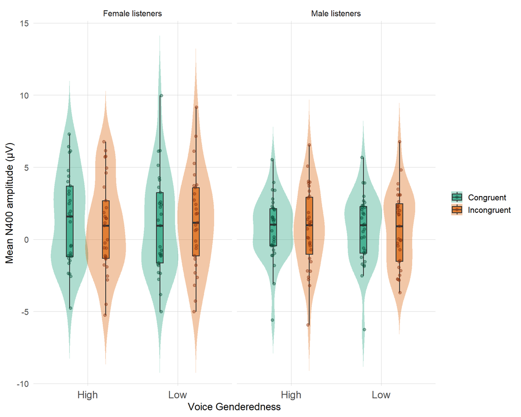

```r
plot_data_stereotype <- exp2_all_data %>%
  group_by(ParticipantID, PtpGender, VoiceGenderedness, Congruency) %>%
  summarise(mean_value = mean(value, na.rm = TRUE), .groups = "drop")

p5a <- ggplot(
  plot_data_stereotype,
  aes(x = VoiceGenderedness, y = mean_value, fill = as_plot_congruency(Congruency))
) +
  geom_violin(
    position = position_dodge(0.8),
    trim = FALSE,
    alpha = 0.35,
    color = NA
  ) +
  geom_boxplot(
    position = position_dodge(0.8),
    width = 0.15,
    outlier.shape = NA,
    alpha = 0.7
  ) +
  geom_jitter(
    aes(color = as_plot_congruency(Congruency)),
    position = position_jitterdodge(
      jitter.width = 0.08,
      dodge.width = 0.8
    ),
    alpha = 0.4,
    size = 1.6
  ) +
  scale_fill_manual(values = CONGRUENCY_COLORS, breaks = CONGRUENCY_PLOT_LEVELS) +
  scale_color_manual(values = CONGRUENCY_DOT_COLORS, breaks = CONGRUENCY_PLOT_LEVELS) +
  facet_wrap(
    ~ PtpGender,
    nrow = 1,
    labeller = as_labeller(c("Female" = "Female listeners", "Male" = "Male listeners"))
  ) +
  coord_cartesian(ylim = c(-9, 14)) +
  labs(
    subtitle = NULL,
    x = "Voice Genderedness",
    y = "Mean N400 amplitude (µV)",
    fill = NULL,
    color = NULL
  ) +
  create_plot_theme(base_size = BaseSize) +
  theme(
    axis.text.x = element_text(size = 14),
    legend.position = "right"
  )

p5a
```

```r
# ggsave("./Figures/Exp2_stereotype_main_violin_p5a.svg", plot = p5a, device = "svg",
#        width = 8, height = 6, units = "in")
```

## 4.4 Analysis 2: Focusing on female participants hearing highly gendered voices

Following the results of Analysis 1, we focus on the subset of data with female participants hearing highly genderedvoices and add trial order as a fixed-effects predictor.

Trial order produces a significant main effect on N400 amplitude, but no significant interaction with Congruency.

```r
exp2_data_female_high <- exp2_all_data %>%
  filter(PtpGender == "Female", VoiceGenderedness == "High") %>%
  mutate(Order_c = Order - mean(Order))   # Re-center Order for this subset

exp2_model_female_high <- run_lmer_model(
  value ~ Congruency * Order_c +
    (1 | ParticipantID) + (1 | WordID) + (1 | ChLabel),
  data = exp2_data_female_high
)
```

```
## Linear mixed model fit by maximum likelihood . t-tests use Satterthwaite's
##   method [lmerModLmerTest]
## Formula: formula
##    Data: data
## Control: control
##
##       AIC       BIC    logLik -2*log(L)  df.resid
##  218685.7  218752.5 -109334.9  218669.7     31036
##
## Scaled residuals:
##     Min      1Q  Median      3Q     Max
## -4.5858 -0.6410  0.0171  0.6583  4.8865
##
## Random effects:
##  Groups        Name        Variance Std.Dev.
##  WordID        (Intercept)  4.23935 2.0590
##  ParticipantID (Intercept)  9.72436 3.1184
##  ChLabel       (Intercept)  0.03017 0.1737
##  Residual                  65.76458 8.1095
## Number of obs: 31044, groups:  WordID, 192; ParticipantID, 29; ChLabel, 6
##
## Fixed effects:
##                          Estimate    Std. Error            df t value
## (Intercept)             1.1032418     0.6038177    33.7178902   1.827
## Congruency1            -0.4914433     0.0922907 30846.8670456  -5.325
## Order_c                -0.0085874     0.0004232 30876.2822881 -20.291
## Congruency1:Order_c    -0.0008699     0.0008388 30852.5199303  -1.037
##                        Pr(>|t|)
## (Intercept)              0.0765 .
## Congruency1         0.000000102 ***
## Order_c                 < 2e-16 ***
## Congruency1:Order_c      0.2997
## ---
## Signif. codes:  0 '***' 0.001 '**' 0.01 '*' 0.05 '.' 0.1 ' ' 1
##
## Correlation of Fixed Effects:
##             (Intr) Cngrn1 Ordr_c
## Congruency1 0.000
## Order_c     0.001  0.011
## Cngrncy1:O_ 0.001  0.001  0.011
##
## Analysis of Deviance Table (Type III Wald chisquare tests)
##
## Response: value
##                       Chisq Df  Pr(>Chisq)
## (Intercept)          3.3383  1     0.06768 .
## Congruency          28.3551  1 0.000000101 ***
## Order_c            411.7063  1   < 2.2e-16 ***
## Congruency:Order_c   1.0755  1     0.29971
## ---
## Signif. codes:  0 '***' 0.001 '**' 0.01 '*' 0.05 '.' 0.1 ' ' 1
```

```r
## removing Congruency : Order_c
exp2_model_female_high <- run_lmer_model(
  value ~ Congruency + Order_c +
    (1 | ParticipantID) + (1 | WordID) + (1 | ChLabel),
  data = exp2_data_female_high
)
```

```
## Linear mixed model fit by maximum likelihood . t-tests use Satterthwaite's
##   method [lmerModLmerTest]
## Formula: formula
##    Data: data
## Control: control
##
##       AIC       BIC    logLik -2*log(L)  df.resid
##  218684.8  218743.2 -109335.4  218670.8     31037
##
## Scaled residuals:
##     Min      1Q  Median      3Q     Max
## -4.5841 -0.6407  0.0177  0.6567  4.8947
##
## Random effects:
##  Groups        Name        Variance Std.Dev.
##  WordID        (Intercept)  4.23911 2.0589
##  ParticipantID (Intercept)  9.72274 3.1181
##  ChLabel       (Intercept)  0.03017 0.1737
##  Residual                  65.76691 8.1097
## Number of obs: 31044, groups:  WordID, 192; ParticipantID, 29; ChLabel, 6
##
## Fixed effects:
##                  Estimate    Std. Error            df t value    Pr(>|t|)
## (Intercept)     1.1037782     0.6037701    33.7180471   1.828      0.0764 .
## Congruency1    -0.4913816     0.0922923 30846.8659192  -5.324 0.000000102 ***
## Order_c        -0.0085826     0.0004232 30876.2548667 -20.280     < 2e-16 ***
## ---
## Signif. codes:  0 '***' 0.001 '**' 0.01 '*' 0.05 '.' 0.1 ' ' 1
##
## Correlation of Fixed Effects:
##             (Intr) Cngrn1
## Congruency1 0.000
## Order_c     0.001  0.011
##
## Analysis of Deviance Table (Type III Wald chisquare tests)
##
## Response: value
##                Chisq Df   Pr(>Chisq)
## (Intercept)   3.3421  1      0.06753 .
## Congruency   28.3470  1 0.0000001014 ***
## Order_c     411.2839  1    < 2.2e-16 ***
## ---
## Signif. codes:  0 '***' 0.001 '**' 0.01 '*' 0.05 '.' 0.1 ' ' 1
```

```r
## Augment the random effects structure
exp2_model_female_high <- run_lmer_model(
  value ~ Congruency + Order_c +
    (1 + Congruency + Order_c | ParticipantID) + (1 + Congruency + Order_c | WordID) + (1 | ChLabel),
  data = exp2_data_female_high,
  auto_simplify = TRUE,
  time_limit = 600
)
```

```
## ======================================================
## === Searching for optimal RE structure
## === Fixed effects: value ~ Congruency + Order_c
## ======================================================
##
## Testing 3 candidate RE structure(s)...
##
## [1/3] maximal (correlated)
##        RE:  (1 + Congruency + Order_c | ParticipantID) + (1 + Congruency + Order_c | WordID) + (1 | ChLabel)
##   -> Timed out after 600 s. Skipping.
##
## [2/3] maximal (uncorrelated)
##        RE:  (1 | ParticipantID) + (0 + Congruency | ParticipantID) + (0 + Order_c | ParticipantID) + (1 | WordID) + (0 + Congruency | WordID) + (0 + Order_c | WordID) + (1 | ChLabel)
##   -> Timed out after 600 s. Skipping.
##
## [3/3] intercepts only
##        RE:  (1 | ParticipantID) + (1 | WordID) + (1 | ChLabel)
##   -> Singular: FALSE | Gradient: (unavailable) | Optimizer warnings: FALSE
##   -> OPTIMAL: converged. Using this RE structure.
##
##   Re-fitting with REML = TRUE...
## ======================================================
## === Optimal RE structure found: intercepts only
## ======================================================
##
## Linear mixed model fit by REML. t-tests use Satterthwaite's method [
## lmerModLmerTest]
## Formula: refit_formula
##    Data: data
## Control: control
##
## REML criterion at convergence: 218686.6
##
## Scaled residuals:
##     Min      1Q  Median      3Q     Max
## -4.5839 -0.6407  0.0177  0.6566  4.8946
##
## Random effects:
##  Groups        Name        Variance Std.Dev.
##  WordID        (Intercept)  4.24072 2.0593
```

[output cut: 12 more lines]

```
##
## Correlation of Fixed Effects:
##             (Intr) Cngrn1
## Congruency1 0.000
## Order_c     0.001  0.011
##
## Analysis of Deviance Table (Type III Wald chisquare tests)
##
## Response: value
##                Chisq Df   Pr(>Chisq)
## (Intercept)   3.2424  1      0.07176 .
## Congruency   28.3448  1 0.0000001015 ***
## Order_c     411.2760  1    < 2.2e-16 ***
## ---
## Signif. codes:  0 '***' 0.001 '**' 0.01 '*' 0.05 '.' 0.1 ' ' 1
```

Plot the Congruency effect across Order (centered) among Female participants with highly gendered voices (Fig.6).

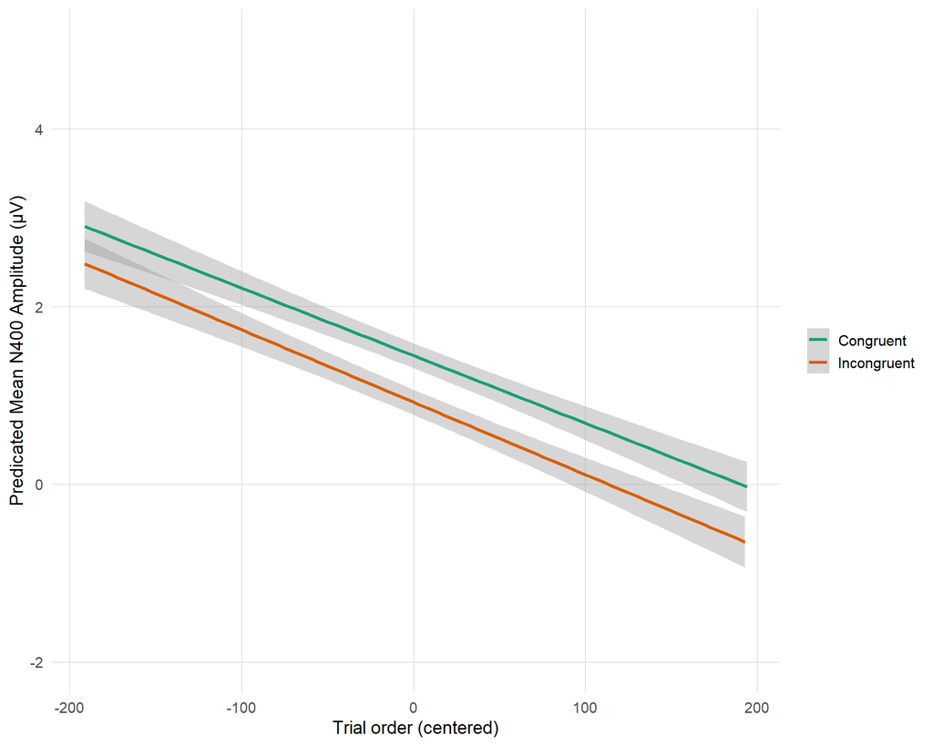

```r
p6 <- create_adaptation_plot(
  data = exp2_data_female_high,
  x_var = "Order_c",
  title = NULL,
  subtitle = NULL,
  ylim = c(-2, 5),
  )+
  labs(x = "Trial order (centered)",
       y = "Predicated Mean N400 Amplitude (μV)") +
  labs(color = NULL) +
  theme(legend.position = "right")
p6
```

```r
# ggsave("./Figures/Exp2_female_high_order_svg.svg", plot = p6, device = "svg", width = 8, height = 4, units = "in")
```